# SNCF: objets trouvés & restitution

## Fabien Pesquerel

### 5 novembre 2023

# Importation des donnée & modifications préliminaires

```python
import numpy as np
import pandas as pd
import matplotlib.pyplot as plt
```

```python
sncf_data = pd.read_csv('objets-trouves-restitution.csv', sep=";")
```

```python
sncf_data["Date"] = sncf_data["Date"].astype("string")
full_date = sncf_data['Date'].str.split('T')
date = full_date.str[0].str.split('-')
hour = full_date.str[1].str.split('+').str[0].str.split(':')
sncf_data["Year"] = date.str[0].astype(int)
sncf_data["Month"] = date.str[1].astype(int)
sncf_data["Day"] = date.str[2].astype(int)
sncf_data["Hour"] = hour.str[0].astype(int)
```

```python
sncf_data
```

|  | Date | Date et heure de restitution | Gare | Code UIC | Nature d'objets | Type d'objets | Type d'enregistrement | Year | Month | Day | Hour |
| --- | --- | --- | --- | --- | --- | --- | --- | --- | --- | --- | --- |
| 0 | 2018-01-05T05:51:16+01:00 | NaN | Caen | 87444000.0 | Foulard, écharpe | Vêtements, chaussures | Objet trouvé | 2018 | 1 | 5 | 5 |
| 1 | 2018-01-05T06:43:28+01:00 | NaN | Tourcoing | 87286542.0 | Carte Vitale | Pièces d'identités et papiers personnels | Objet trouvé | 2018 | 1 | 5 | 6 |
| 2 | 2018-01-05T06:49:34+01:00 | NaN | Tourcoing | 87286542.0 | Sacoche pour ordinateur, photo, vidéo | Bagagerie: sacs, valises, cartables | Objet trouvé | 2018 | 1 | 5 | 6 |
| 3 | 2018-01-05T08:44:24+01:00 | NaN | Lille Europe | 87223263.0 | Carte d'abonnement | Pièces d'identités et papiers personnels | Objet trouvé | 2018 | 1 | 5 | 8 |
| 4 | 2018-01-05T09:11:04+01:00 | 2018-01-06T15:13:14+01:00 | Bordeaux Saint-Jean | 87581009.0 | Sac à dos | Bagagerie: sacs, valises, cartables | Objet trouvé | 2018 | 1 | 5 | 9 |
| ... | ... | ... | ... | ... | ... | ... | ... | ... | ... | ... | ... |
| 828004 | 2017-11-14T17:44:24+01:00 | NaN | Marseille Saint-Charles | 87751008.0 | Carte de crédit | Porte-monnaie / portefeuille, argent, titres | Objet trouvé | 2017 | 11 | 14 | 17 |
| 828005 | 2017-11-14T17:51:26+01:00 | NaN | Rennes | 87471003.0 | Carte d'identité, passeport, permis de conduire | Pièces d'identités et papiers personnels | Objet trouvé | 2017 | 11 | 14 | 17 |
| 828006 | 2017-11-14T18:23:30+01:00 | NaN | Hendaye | 87677005.0 | Ordinateur, ordinateur portable, notebook | Appareils électroniques, informatiques, appare... | Objet trouvé | 2017 | 11 | 14 | 18 |
| 828007 | 2017-11-14T18:51:57+01:00 | NaN | Tourcoing | 87286542.0 | Autre bagagerie | Bagagerie: sacs, valises, cartables | Objet trouvé | 2017 | 11 | 14 | 18 |
| 828008 | 2017-11-14T21:07:22+01:00 | 2017-11-16T17:27:40+01:00 | Angers Saint-Laud | 87484006.0 | Attaché-case, serviette | Bagagerie: sacs, valises, cartables | Objet trouvé | 2017 | 11 | 14 | 21 |

828009 rows × 11 columns

# Analyse

## Pourcentage d'objets restitués

```python
non_nan = sncf_data.count()
restituted_object = non_nan["Date et heure de restitution"] / sncf_data.shape[0]
known_location = non_nan["Gare"] / sncf_data.shape[0]
print(100*restituted_object, 100*known_location)
```

```
37.336429918032294 99.95966227420233
```

## Répartitions des objets trouvés

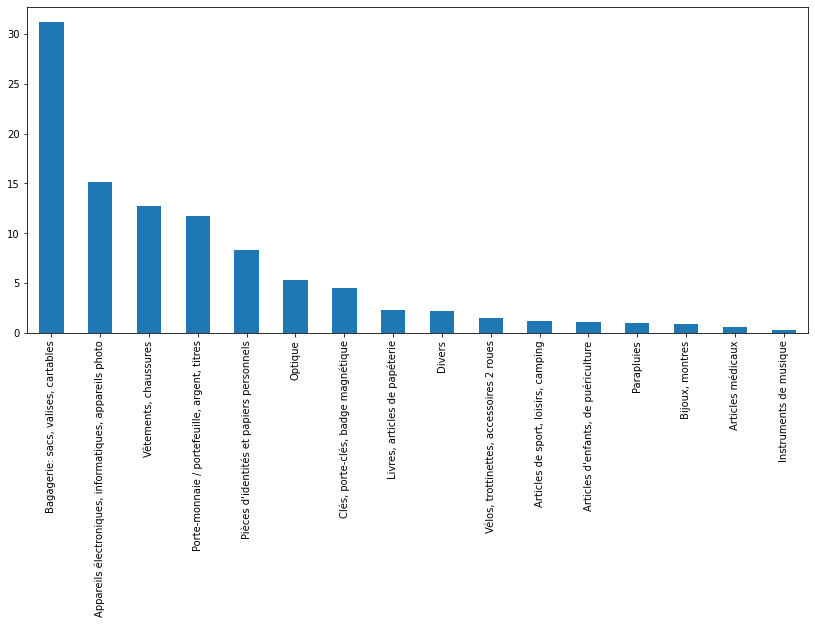

```python
obj = sncf_data["Type d'objets"].value_counts()
obj = 100 * obj / obj.sum()
obj.plot(kind="bar", figsize=(14, 6))
plt.show()
```

```python
obj[0:5], obj[0:5].sum()
```

```
(Bagagerie: sacs, valises, cartables                        31.145797
 Appareils électroniques, informatiques, appareils photo    15.164449
 Vêtements, chaussures                                      12.711094
 Porte-monnaie / portefeuille, argent, titres               11.726926
 Pièces d'identités et papiers personnels                    8.340127
 Name: Type d'objets, dtype: float64,
 79.08839155129957)
```

On observe que plus de 30 % des objets trouvés sont de la catégorie *Bagagerie: sacs, valises, cartables*, environ 15 % sont de la catégorie *Appareils électroniques, informatiques, appareils photo*, 13 % *Vêtements, chaussures*, 12 % *Porte-monnaie / portefeuille, argent, titres*, et 8 % *Pièces d'identités et papiers personnels*.

Ces 5 catégories représentent 79 % des objets trouvés.

Si on devait utiliser ces données pour décider d'un message de rappel aux voyageurs, on pourrait imaginer se concentrer sur ces catégories pour maximiser l'efficacité du message (en imaginant que l'efficacité d'un message mesure son impact sur la diminution d'objets trouvés).

## Analyse par année

```python
per_year_restititution = {d:{"lost":None, "retrieved":None, "percent":None} for d in sncf_data["Year"].unique()}
for d in sncf_data["Year"].unique():
    date_count = sncf_data.loc[sncf_data['Year'] == d].count()
    # print(d, date_count, date_count.shape)
    per_year_restititution[d]["retrieved"] = date_count["Date et heure de restitution"]
    per_year_restititution[d]["lost"] = date_count["Date"]
    per_year_restititution[d]["percent"] = 100*date_count["Date et heure de restitution"] / date_count["Date"]
```

```python
x = sorted(list(per_year_restititution.keys()))[1:]
y_lost = [per_year_restititution[k]["lost"] for k in x]
y_retrieved = [per_year_restititution[k]["retrieved"] for k in x]
y_percent = [per_year_restititution[k]["percent"] for k in x]
```

On affiche d'abord le nombre d'objets trouvés par an.

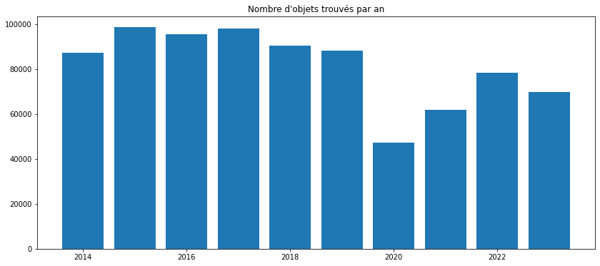

```python
plt.figure(figsize = (14,6))
plt.title("Nombre d'objets trouvés par an")
plt.bar(x, y_lost)
plt.show()
```

On voit bien qu'un événement particulier s'est déroulé vers 2020-2021. L'épidémie de COVID-19 explique sans doute cette chute du nombre d'objets trouvés. Pour confirmer cette hypothèse expliquant la forme de l'histogramme, il faudrait rapporter le nombre d'objets trouvés au nombre de voyageurs.

On affiche maintenant le pourcentage d'objets restitués par an; c'est-à-dire qu'on donne, par année, la proportion du nombre objets restitués sur le nombre d'objets trouvés.

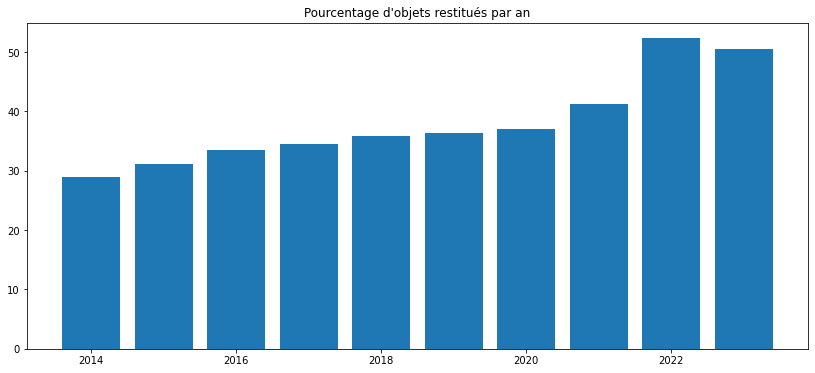

```python
plt.figure(figsize = (14,6))
plt.title("Pourcentage d'objets restitués par an")
plt.bar(x, y_percent)
plt.show()
```

On observe une augmentation lente du pourcentage d'objets restitués depuis 2014 jusqu'en 2021 puis une augmentation drastique du pourcentage d'objets restitués en 2022 avec stabilisation de cette proportion pour 2023. Je n'ai pas d'hypothèse de travail permettant d'expliquer cette brusque variation.

## Analyse par mois

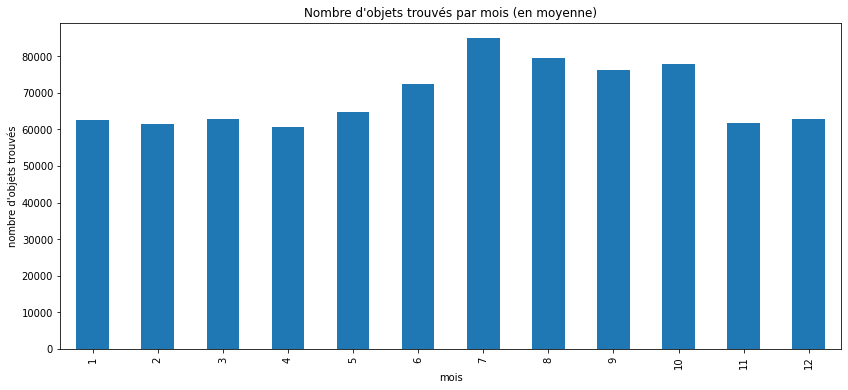

```python
a = sncf_data["Month"].value_counts()
plt.title("Nombre d'objets trouvés par mois (en moyenne)")
a.sort_index().plot(kind='bar', figsize=(14,6))
plt.xlabel('mois')
plt.ylabel("nombre d'objets trouvés")
plt.show()
```

On voit que ce sont les mois de juillet-août qui enregistre le plus grand nombre d'objets trouvés. Une explication est sans doute l'augmentation du nombre de voyageurs, ce qui doit être confirmé avec un autre jeu de données.

On observe sur les mois de juillet-août, un surplus moyen de 13 000 objets trouvés de plus par mois, c'est-à-dire qu'on trouve au mois de juillet 13 000 objets de plus qu'en moyenne (L'écart est encore plus significatif si on calcule la moyenne en excluant juillet et août).

```python
(a[7]+a[8]) / 2 - a.sum() / 12
```

```
13229.25
```

Regardons un peu plus les données pour tenter d'expliquer cet écart.

```python
df = pd.DataFrame()
for i in range(1,13):
    d = sncf_data.loc[sncf_data["Month"] == i]["Type d'objets"].value_counts()
    df[i] = d
```

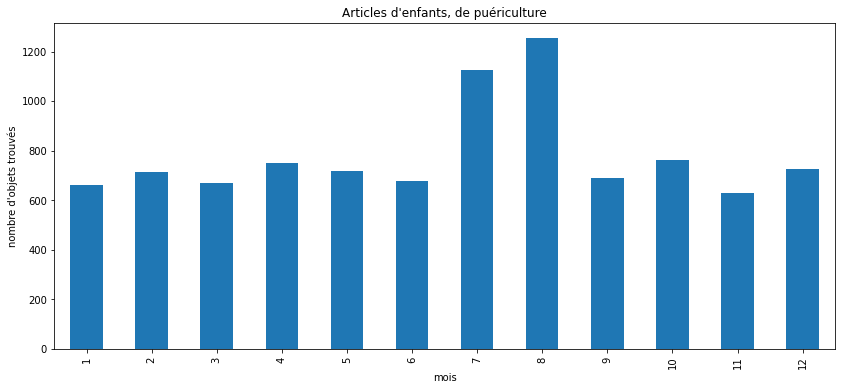

```python
plt.title(df.iloc[11].name)
df.iloc[11].plot(kind='bar', figsize=(14, 6))
plt.xlabel('mois')
plt.ylabel("nombre d'objets trouvés")
plt.show()
```

```python
(df.iloc[11][7]+df.iloc[11][8]) / 2 - df.iloc[11].sum() / 12
```

```
408.33333333333337
```

On voit qu'un surplus moyen mensuel de 410 objets s'explique par les articles d'enfants, ce qui est cohérent avec notre intuition de la période estivale. Cette intuition peut se confirmer par une analyse plus fine du profil moyen des voyageurs, en particulier du nombre d'enfants par mois.

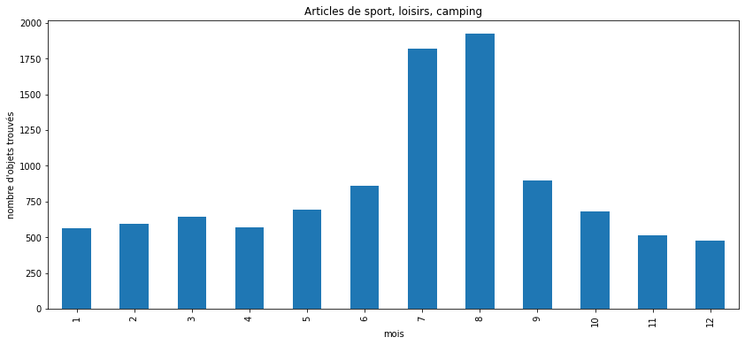

```python
plt.title(df.iloc[13].name)
df.iloc[13].plot(kind='bar', figsize=(14, 6))
plt.xlabel('mois')
plt.ylabel("nombre d'objets trouvés")
plt.show()
```

```python
(df.iloc[13][7]+df.iloc[13][8]) / 2 - df.iloc[13].sum() / 12
```

```
1017.3333333333334
```

On voit qu'un surplus moyen mensuel de 1017 objets s'explique par les articles de sports et de loisirs, ce qui est cohérent avec notre intuition de la période estivale. Cette intuition peut se confirmer par une analyse plus fine du profil moyen des voyageurs, en particulier du nombre de vacanciers.

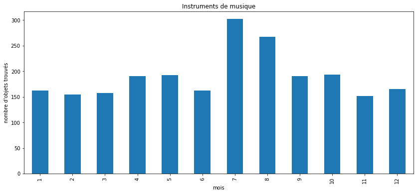

```python
plt.title(df.iloc[15].name)
df.iloc[15].plot(kind='bar', figsize=(14, 6))
plt.xlabel('mois')
plt.ylabel("nombre d'objets trouvés")
plt.show()
```

```python
(df.iloc[15][7]+df.iloc[15][8]) / 2 - df.iloc[15].sum() / 12
```

```
93.5
```

On voit qu'un surplus moyen mensuel de 94 objets s'explique par les instruments de musique. Je n'avais pas vraiment anticipé celui-ci mais une investigation plus pousée permettrait sans-doute de mieux comprendre ce maximal estival de l'histogramme (les guitares ou fanfares ?).

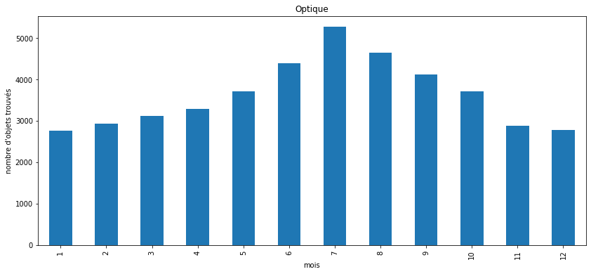

```python
plt.title(df.iloc[6].name)
df.iloc[6].plot(kind='bar', figsize=(14, 6))
plt.xlabel('mois')
plt.ylabel("nombre d'objets trouvés")
plt.show()
```

```python
(df.iloc[6][7]+df.iloc[6][8]) / 2 - df.iloc[6].sum() / 12
```

```
1320.3333333333335
```

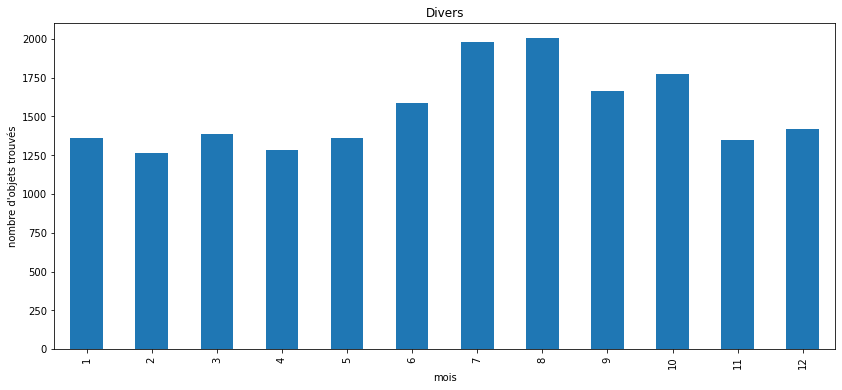

```python
plt.title(df.iloc[8].name)
df.iloc[8].plot(kind='bar', figsize=(14, 6))
plt.xlabel('mois')
plt.ylabel("nombre d'objets trouvés")
plt.show()
```

```python
(df.iloc[8][7]+df.iloc[8][8]) / 2 - df.iloc[8].sum() / 12
```

```
455.41666666666674
```

Enfin, on observe un maximal d'histogramme estival pour les objets divers.

Ces catégories expliquent une partie (environ 25 %) de la spécifité de la période estivale. Le reste est sans doute expliqué par le plus grand nombre de voyageurs. Il faudrait pour cela pouvoir rapporter le nombre d'objets trouvés au nombre de voyageurs. Une analyse encore plus fine tiendrait compte des lignes.

## Analyse par heure

Après avoir brievement regardé la dépendance du nombre d'objets trouvés par mois, on peut se demander s'il y a une dépendance horaire. Évidemment, pour pouvoir être le plus pertinent possible, il faudrait pouvoir tout rapporter au nombre de voyageurs par heure.

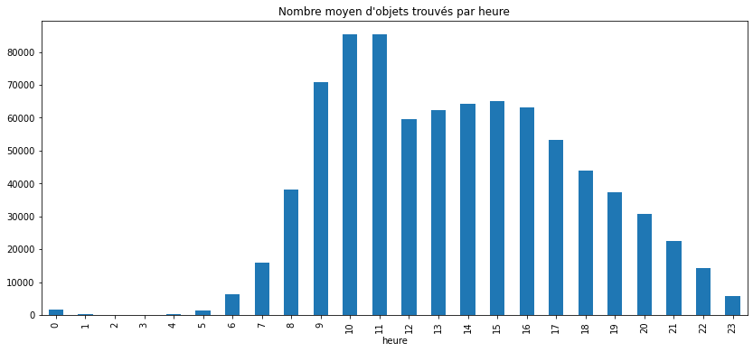

```python
a = sncf_data["Hour"].value_counts()
plt.title("Nombre moyen d'objets trouvés par heure")
a.sort_index().plot(kind='bar', figsize=(14,6))
plt.xlabel('heure')
plt.show()
```

On voit un pique aux alentours de 9-10-11 heures. Ce pique peut être expliqué par le nombre de voyageurs. Une autre hypothèse permet probablement d'expliquer une partie de ce pique.

Si on imagine qu'il y a des voyageurs qui font deux trajets par jour, un aller le matin et un retour le soir, alors s'ils perdent des affaires le matin, ils ne peuvent pas les perdre le soir. Ainsi, il y aura mécaniquement plus de pertes le matin que le soir.

On peut modéliser ce phénomène par le fait qu'un passager à une probabilité $p$ d'oublier un objet lors d'un trajet et qu'il ne peut pas l'oublier au retour s'il l'a déjà oublié à l'aller.

Si le passager possède un objet, et qu'il fait deux trajets, un le matin et un le soir, la probabilité d'oublier l'objet le matin est $p$ alors qu'elle est de $p(1-p)$ le soir. Si on note $n$ le nombre de ce genre de voyageurs, et $\Delta$ la différence entre le nombre de bagages trouvés le matin et le nombre de bagages trouvés le soir, alors on a $n p^2 = \Delta$. Connaissant le nombre de voyageurs, on peut en déduire la probabilité d'oubli $p = \sqrt{\frac{\Delta}{n}}$.

Cette probabilité $p$ permet de mesurer l'efficacité d'un message de rappel. En effet, on peut considérer qu'un message est plus efficace qu'un autre s'il fait diminuer la probabilité qu'un voyageur oubli un objet. Ainsi, plutôt que de mesurer le nombre brut de bagages oubliés, on peut plutôt s'intéresser à un nombre indépendant du nombre de voyageurs pour mesurer l'efficacité de mesure contre l'oubli de bagage. Évidemment, il y a d'autres modèles et moyen d'estimer la probabilité $p$. De plus, une analyse plus fine montre sans doute que $p$ dépend du profil du voyageur.

On peut calculer par heure, la répartition des types d'objets trouvés.

```python
df = pd.DataFrame()
for i in range(24):
    d = sncf_data.loc[sncf_data["Hour"] == i]["Type d'objets"].value_counts()
    d = 100 * d / d.sum()
    df[i] = d
```

On affiche pour quelques catégories, les histogrammes qui donnent le pourcentage d'objets trouvés appartenant à ladite catégorie par heure.

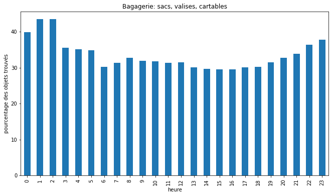

```python
plt.figure(figsize=(11,6))
df.iloc[0].plot(kind='bar', title=df.iloc[0].name)
plt.xlabel('heure')
plt.ylabel('pourcentage des objets trouvés')
plt.show()
```

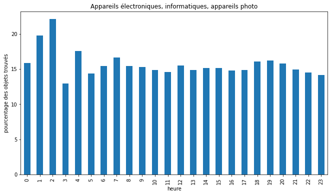

```python
plt.figure(figsize=(11,6))
df.iloc[1].plot(kind='bar', title=df.iloc[1].name)
plt.xlabel('heure')
plt.ylabel('pourcentage des objets trouvés')
plt.show()
```

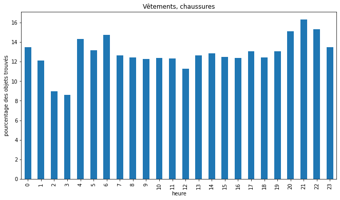

```python
plt.figure(figsize=(11,6))
df.iloc[2].plot(kind='bar', title=df.iloc[2].name)
plt.xlabel('heure')
plt.ylabel('pourcentage des objets trouvés')
plt.show()
```

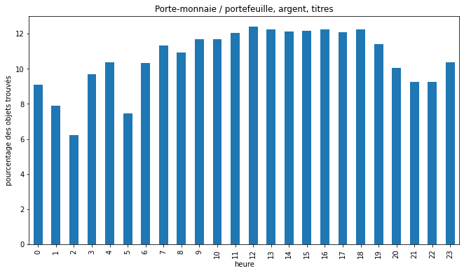

```python
plt.figure(figsize=(11,6))
df.iloc[3].plot(kind='bar', title=df.iloc[3].name)
plt.xlabel('heure')
plt.ylabel('pourcentage des objets trouvés')
plt.show()
```

Il est difficile de donner une interprétaton pertinente de ces histogrammes sans un recoupage avec le nombre de voyageurs, en particulier pour calculer des intervalles de confiance.